# Assignment 1 (due on 10/13)

# 学生：单雪鹏 (12132031)，Github: PickleRick2042

# 得分：70/100

## PS1 Flowchart

```python
#1.Flowchart
a=int(input())
b=int(input())
c=int(input())
d=[a,b,c]
d.sort()
print(d)
```

```
9
4
6
[4, 6, 9]
```

# PS1 代码运行正常，可以输出结果，但是题目要求的是降序排列，且没有将函数打包进`Print_values()`，另外需要在报告中展示输出结果。同时，建议在代码和报告中补充原a,b,c的打印。

# 得分：6/10

# ----------------------------------------------------

# PS2 Matrix multiplication

```python
import numpy as np
M1=np.random.randint(0,50,(10,5))
print(M1)
M2=np.random.randint(0,50,(5,10))
print(M2)
M3=np.dot(M2, M1)
print(M3)
```

```
[[27  6 29 28 36]
 [16 23 20 31 49]
 [25 22  3  4  7]
 [45 24  1 21 10]
 [40 30  7 37  8]
 [46 43  4 37 46]
 [44 40 35 29 18]
 [15 16 33 17 31]
 [27 38 10 37 18]
 [16  1  1 35 19]]
[[43 44 22 10  6 47 40  8 37 30]
 [ 9 22 41 11 10 40 10 27 49 48]
 [40 49 31 16 20 23 34 43 49  4]
 [43 32 44 31  5 31 31 22 23 10]
 [14  6 10 20 39 26 24 24 32 11]]
[[8626 7359 4497 8542 8372]
 [7291 6488 2844 7421 6530]
 [8745 7936 5584 8360 8339]
 [8269 6665 4260 6829 7044]
 [6836 5781 2916 6116 4537]]
```

```python
# TA test
print("TA test (result should be a matrix full of True)")
print(np.matmul(M2, M1) == M3) # should be True
```

```
TA test (result should be a matrix full of True)
[[ True  True  True  True  True]
 [ True  True  True  True  True]
 [ True  True  True  True  True]
 [ True  True  True  True  True]
 [ True  True  True  True  True]]
```

# PS2 代码运行正常，可以输出正确结果，但是需要在报告中展示输出结果。本题中采用了现成的矩阵运算函数直接得出结果，建议还可以尝试下按照矩阵相乘的原理写一份代码，并封装进 `Matrix_multip` 函数，进行检验比较。

# 得分：12/15

# ----------------------------------------------------

# PS3 Pascal triangle

```python
def Pascal_triangle():
    L=[1]
    while True:
        yield L
        L=[1]+[L[i-1]+L[i] for i in range(1,len(L))]+[1]

n=0
for i in Pascal_triangle():
    print(i)
    n+=1
    if n>100:
        break
```

```
[1]
[1, 1]
[1, 2, 1]
[1, 3, 3, 1]
[1, 4, 6, 4, 1]
[1, 5, 10, 10, 5, 1]
[1, 6, 15, 20, 15, 6, 1]
[1, 7, 21, 35, 35, 21, 7, 1]
[1, 8, 28, 56, 70, 56, 28, 8, 1]
[1, 9, 36, 84, 126, 126, 84, 36, 9, 1]
[1, 10, 45, 120, 210, 252, 210, 120, 45, 10, 1]
[1, 11, 55, 165, 330, 462, 462, 330, 165, 55, 11, 1]
[1, 12, 66, 220, 495, 792, 924, 792, 495, 220, 66, 12, 1]
[1, 13, 78, 286, 715, 1287, 1716, 1716, 1287, 715, 286, 78, 13, 1]
[1, 14, 91, 364, 1001, 2002, 3003, 3432, 3003, 2002, 1001, 364, 91, 14, 1]
```

[output cut: 86 more lines]

```python
N=0
for i in Pascal_triangle():
    print(i)
    N+=1
    if N>200:
        break
```

```
[1]
[1, 1]
[1, 2, 1]
[1, 3, 3, 1]
[1, 4, 6, 4, 1]
[1, 5, 10, 10, 5, 1]
[1, 6, 15, 20, 15, 6, 1]
[1, 7, 21, 35, 35, 21, 7, 1]
[1, 8, 28, 56, 70, 56, 28, 8, 1]
[1, 9, 36, 84, 126, 126, 84, 36, 9, 1]
[1, 10, 45, 120, 210, 252, 210, 120, 45, 10, 1]
[1, 11, 55, 165, 330, 462, 462, 330, 165, 55, 11, 1]
[1, 12, 66, 220, 495, 792, 924, 792, 495, 220, 66, 12, 1]
[1, 13, 78, 286, 715, 1287, 1716, 1716, 1287, 715, 286, 78, 13, 1]
[1, 14, 91, 364, 1001, 2002, 3003, 3432, 3003, 2002, 1001, 364, 91, 14, 1]
```

[output cut: 186 more lines]

# PS3 代码运行正常，可以输出打印结果，但是仍存在一个迭代次数问题，即第100 line的输出应当是[1,99,...99,1]，输出中的[1,100,...,100,1]对应的应该是101 line，200 line的输出也有相同问题，另外需要在报告中展示输出结果。

# 得分：18/20

# ----------------------------------------------------

# PS4 Add or double

```python
x=int(input())
count=0
while x!=1:
    if x%2==0:
        x/=2
    else:
        x-=1
    count+=1
print(count)
```

```
50
7
```

# 代码输出结果正确，但是没有将代码封装进 `Least_moves()` 函数中，另外需要在报告中展示结果。

# 得分 17/20

# ----------------------------------------------------

# PS5 Dynamic programming

```python
from itertools import product
m=int(input())
n = 0
for s in product('+-*/ ', repeat = 8):
    e=""

for i in range(1, 9):

    assert(len(s) > 0)

e += '%d' % i

if (s[0] != ' '):

    e += s[0]

s = s[1:]

e += '9'

if eval(e) ==m:

    n += 1

print('%d#' % n, end = '\t')
print('%s=m' % e)
```

```
50
0#	89=m
```

# 代码无法正常输出，主要可能是缩进问题，无法打印出公式。另外需要把计算代码整合进 `Find_expression()` 函数中，本题结果也需要展示在报告上。

# 得分 17/30

# 第二部分的Total_solutions列表没有画出来，同时没有给出问题的答案。

# 得分 0/5

# 下方代码为Wenfu-Sun提供的针对PS5的参考代码，供你参考，一起讨论。

```python
import numpy as np
import itertools as itls
import matplotlib.pyplot as plt

def Find_expression(value, i=0): # 用于找到表达式和表达式数量，并打印出来。
    array = itls.product(['+','-',''], repeat=8) # 枚举法
    for ops in array:
        expr = f"1{ops[0]}2{ops[1]}3{ops[2]}4{ops[3]}5{ops[4]}6{ops[5]}7{ops[6]}8{ops[7]}9"
        if eval(expr) == value: # eval() 函数用来执行一个字符串表达式，并返回表达式的值。
            i+=1
            print(expr, f"={value}")
    print("total num of expr is: " + str(i))
    return i

def Find_expression_num(value, i=0): # 用于找到表达式的数量
    array = itls.product(['+','-',''], repeat=8)
    for ops in array:
        expr = f"1{ops[0]}2{ops[1]}3{ops[2]}4{ops[3]}5{ops[4]}6{ops[5]}7{ops[6]}8{ops[7]}9"
        if eval(expr) == value: # eval() 函数用来执行一个字符串表达式，并返回表达式的值。
            i+=1
    return i

def find_num(item, count_list): # 用于找出目标数字的在list中的位置
    idx_list = []
    for index, element in enumerate(count_list):
        if element == item:
            idx_list.append(index+1)
#             print(index+1, end=" ")
    return idx_list
```

```python
Find_expression(100)
```

```
1+2+3-4+5+6+78+9 =100
1+2+34-5+67-8+9 =100
1+23-4+5+6+78-9 =100
1+23-4+56+7+8+9 =100
12+3+4+5-6-7+89 =100
12+3-4+5+67+8+9 =100
12-3-4+5-6+7+89 =100
123+4-5+67-89 =100
123+45-67+8-9 =100
123-4-5-6-7+8-9 =100
123-45-67+89 =100
total num of expr is: 11
```

```
11
```

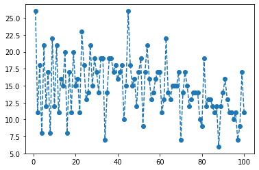

```python
Total_solutions = [Find_expression_num(ivalue, i=0) for ivalue in np.arange(1,101,1)] #定义Find_expression_num函数的返回值为对应数字的表达式数量，然后遍历 1-100，生成一个表达式数量的list。
plt.plot(np.arange(1,101,1),Total_solutions,marker='o',linestyle='dashed')
plt.show()
```

```python
# 找到表达式最少的数字
num_minexpr = find_num(min(Total_solutions),Total_solutions)
print("num with Min exprs: "+str(num_minexpr)+", the amount of exprs: "+str(min(Total_solutions)))

# 找到表达式最多的数字
num_maxexpr = find_num(max(Total_solutions),Total_solutions)
print("num with Max exprs: "+str(num_maxexpr)+", the amount of exprs: "+str(max(Total_solutions)))
```

```
num with Min exprs: [88], the amount of exprs: 6
num with Max exprs: [1, 45], the amount of exprs: 26
```